# Risk Factor Analysis

## Outcome Variable

**Outcome Variable:** haz

## Predictor Variables

**Intervention Variable:** studyid

**Adjustment Set:**

unadjusted

## Stratifying Variables

The analysis was stratified on these variable(s):

- agecat

## Data Summary

| agecat | studyid | n_cell | n | outcome_variable |
| --- | --- | --- | --- | --- |
| Birth | CMC-V-BCS-2002 | 92 | 70599 | haz |
| Birth | CMIN | 26 | 70599 | haz |
| Birth | COHORTS | 10542 | 70599 | haz |
| Birth | CONTENT | 2 | 70599 | haz |
| Birth | EE | 240 | 70599 | haz |
| Birth | GMS-Nepal | 696 | 70599 | haz |
| Birth | Guatemala BSC | 0 | 70599 | haz |
| Birth | IRC | 388 | 70599 | haz |
| Birth | JiVitA-3 | 22455 | 70599 | haz |
| Birth | JiVitA-4 | 2823 | 70599 | haz |
| Birth | Keneba | 1543 | 70599 | haz |
| Birth | LCNI-5 | 0 | 70599 | haz |
| Birth | MAL-ED | 851 | 70599 | haz |
| Birth | NIH-Birth | 608 | 70599 | haz |
| Birth | NIH-Crypto | 732 | 70599 | haz |
| Birth | PROBIT | 13893 | 70599 | haz |
| Birth | PROVIDE | 539 | 70599 | haz |
| Birth | ResPak | 42 | 70599 | haz |
| Birth | SAS-CompFeed | 1252 | 70599 | haz |
| Birth | SAS-FoodSuppl | 0 | 70599 | haz |
| Birth | TanzaniaChild2 | 0 | 70599 | haz |
| Birth | ZVITAMBO | 13875 | 70599 | haz |
| 6 months | CMC-V-BCS-2002 | 369 | 69534 | haz |
| 6 months | CMIN | 243 | 69534 | haz |
| 6 months | COHORTS | 10529 | 69534 | haz |
| 6 months | CONTENT | 215 | 69534 | haz |
| 6 months | EE | 373 | 69534 | haz |
| 6 months | GMS-Nepal | 564 | 69534 | haz |
| 6 months | Guatemala BSC | 299 | 69534 | haz |
| 6 months | IRC | 407 | 69534 | haz |
| 6 months | JiVitA-3 | 16811 | 69534 | haz |
| 6 months | JiVitA-4 | 4831 | 69534 | haz |
| 6 months | Keneba | 2089 | 69534 | haz |
| 6 months | LCNI-5 | 839 | 69534 | haz |
| 6 months | MAL-ED | 1696 | 69534 | haz |
| 6 months | NIH-Birth | 537 | 69534 | haz |
| 6 months | NIH-Crypto | 715 | 69534 | haz |
| 6 months | PROBIT | 15760 | 69534 | haz |
| 6 months | PROVIDE | 604 | 69534 | haz |
| 6 months | ResPak | 239 | 69534 | haz |
| 6 months | SAS-CompFeed | 1336 | 69534 | haz |
| 6 months | SAS-FoodSuppl | 380 | 69534 | haz |
| 6 months | TanzaniaChild2 | 2029 | 69534 | haz |
| 6 months | ZVITAMBO | 8669 | 69534 | haz |
| 24 months | CMC-V-BCS-2002 | 371 | 35072 | haz |
| 24 months | CMIN | 242 | 35072 | haz |
| 24 months | COHORTS | 8852 | 35072 | haz |
| 24 months | CONTENT | 164 | 35072 | haz |
| 24 months | EE | 167 | 35072 | haz |
| 24 months | GMS-Nepal | 488 | 35072 | haz |
| 24 months | Guatemala BSC | 0 | 35072 | haz |
| 24 months | IRC | 409 | 35072 | haz |
| 24 months | JiVitA-3 | 8632 | 35072 | haz |
| 24 months | JiVitA-4 | 4752 | 35072 | haz |
| 24 months | Keneba | 1725 | 35072 | haz |
| 24 months | LCNI-5 | 579 | 35072 | haz |
| 24 months | MAL-ED | 1489 | 35072 | haz |
| 24 months | NIH-Birth | 429 | 35072 | haz |
| 24 months | NIH-Crypto | 514 | 35072 | haz |
| 24 months | PROBIT | 4035 | 35072 | haz |
| 24 months | PROVIDE | 578 | 35072 | haz |
| 24 months | ResPak | 0 | 35072 | haz |
| 24 months | SAS-CompFeed | 0 | 35072 | haz |
| 24 months | SAS-FoodSuppl | 0 | 35072 | haz |
| 24 months | TanzaniaChild2 | 6 | 35072 | haz |
| 24 months | ZVITAMBO | 1640 | 35072 | haz |

The following strata were considered:

- agecat: 24 months
- agecat: 6 months
- agecat: Birth

### Dropped Strata

Some strata were dropped due to rare outcomes:

- agecat: Birth
- agecat: 24 months

## Methods Detail

We’re interested in the causal parameters $E[Y_a]$ for all values of $a \in \mathcal{A}$. These parameters represent the mean outcome if, possibly contrary to fact, we intervened to set all units to have $A=a$. Under the randomization and positivity assumptions, these are identified by the statistical parameters $\psi_a=E_W[E_{Y|A,W}(Y|A=a,W)]$. In addition, we’re interested in the mean of $Y$, $E[Y]$ under no intervention (the observed mean). We will estimate these parameters by using SuperLearner to fit the relevant likelihood factors – $E_{Y|A,W}(Y|A=a,W)$ and $p(A=a|W)$, and then updating our likelihood fit using a joint TMLE.

For unadjusted analyses ($W=\{\}$), initial likelihoods were estimated using Lrnr_glm to estimate the simple $E(Y|A)$ and Lrnr_mean to estimate $p(A)$. For adjusted analyses, a small library containing Lrnr_glmnet, Lrnr_xgboost, and Lrnr_mean was used.

Having estimated these parameters, we will then use the delta method to estimate relative risks and attributable risks relative to a prespecified baseline level of $A$.

# Results Detail

## Results Plots

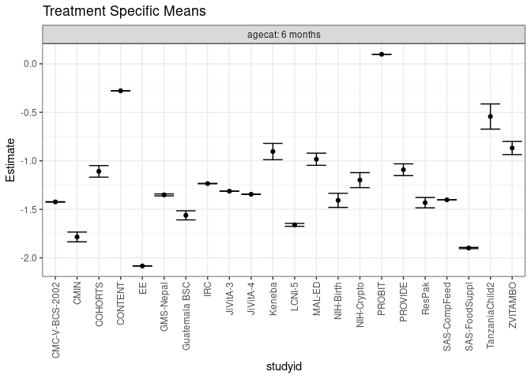

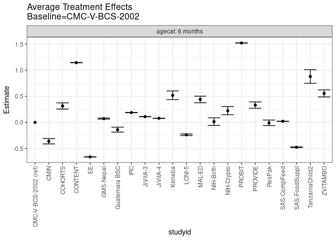

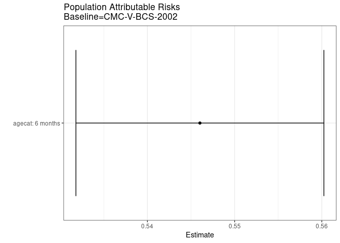

## Results Table

### Parameter: TSM

| agecat | intervention_level | baseline_level | estimate | ci_lower | ci_upper |
| --- | --- | --- | --- | --- | --- |
| 6 months | CMC-V-BCS-2002 | NA | -1.4234508 | -1.4256598 | -1.4212417 |
| 6 months | CMIN | NA | -1.7844376 | -1.8348693 | -1.7340059 |
| 6 months | COHORTS | NA | -1.1085526 | -1.1683167 | -1.0487885 |
| 6 months | CONTENT | NA | -0.2785256 | -0.2796568 | -0.2773943 |
| 6 months | EE | NA | -2.0835567 | -2.0853136 | -2.0817999 |
| 6 months | GMS-Nepal | NA | -1.3508392 | -1.3607182 | -1.3409602 |
| 6 months | Guatemala BSC | NA | -1.5619008 | -1.6088135 | -1.5149881 |
| 6 months | IRC | NA | -1.2344062 | -1.2366532 | -1.2321592 |
| 6 months | JiVitA-3 | NA | -1.3130932 | -1.3144370 | -1.3117494 |
| 6 months | JiVitA-4 | NA | -1.3447940 | -1.3467892 | -1.3427988 |
| 6 months | Keneba | NA | -0.9041369 | -0.9882027 | -0.8200712 |
| 6 months | LCNI-5 | NA | -1.6601907 | -1.6750280 | -1.6453534 |
| 6 months | MAL-ED | NA | -0.9837485 | -1.0463746 | -0.9211225 |
| 6 months | NIH-Birth | NA | -1.4073821 | -1.4799960 | -1.3347682 |
| 6 months | NIH-Crypto | NA | -1.1986783 | -1.2760951 | -1.1212615 |
| 6 months | PROBIT | NA | 0.0980074 | 0.0976001 | 0.0984147 |
| 6 months | PROVIDE | NA | -1.0916915 | -1.1522622 | -1.0311208 |
| 6 months | ResPak | NA | -1.4314086 | -1.4847844 | -1.3780329 |
| 6 months | SAS-CompFeed | NA | -1.4018563 | -1.4020778 | -1.4016348 |
| 6 months | SAS-FoodSuppl | NA | -1.8986842 | -1.9051218 | -1.8922466 |
| 6 months | TanzaniaChild2 | NA | -0.5434389 | -0.6732683 | -0.4136094 |
| 6 months | ZVITAMBO | NA | -0.8679450 | -0.9355882 | -0.8003017 |

### Parameter: E(Y)

| agecat | intervention_level | baseline_level | estimate | ci_lower | ci_upper |
| --- | --- | --- | --- | --- | --- |
| 6 months | NA | NA | -0.877431 | -0.8914874 | -0.8633747 |

### Parameter: ATE

| agecat | intervention_level | baseline_level | estimate | ci_lower | ci_upper |
| --- | --- | --- | --- | --- | --- |
| 6 months | CMC-V-BCS-2002 | CMC-V-BCS-2002 | 0.0000000 | 0.0000000 | 0.0000000 |
| 6 months | CMIN | CMC-V-BCS-2002 | -0.3609868 | -0.4114669 | -0.3105067 |
| 6 months | COHORTS | CMC-V-BCS-2002 | 0.3148982 | 0.2550933 | 0.3747031 |
| 6 months | CONTENT | CMC-V-BCS-2002 | 1.1449252 | 1.1424580 | 1.1473924 |
| 6 months | EE | CMC-V-BCS-2002 | -0.6601060 | -0.6628234 | -0.6573885 |
| 6 months | GMS-Nepal | CMC-V-BCS-2002 | 0.0726115 | 0.0624865 | 0.0827365 |
| 6 months | Guatemala BSC | CMC-V-BCS-2002 | -0.1384500 | -0.1854147 | -0.0914853 |
| 6 months | IRC | CMC-V-BCS-2002 | 0.1890445 | 0.1859903 | 0.1920988 |
| 6 months | JiVitA-3 | CMC-V-BCS-2002 | 0.1103576 | 0.1077613 | 0.1129538 |
| 6 months | JiVitA-4 | CMC-V-BCS-2002 | 0.0786567 | 0.0757194 | 0.0815941 |
| 6 months | Keneba | CMC-V-BCS-2002 | 0.5193138 | 0.4352212 | 0.6034064 |
| 6 months | LCNI-5 | CMC-V-BCS-2002 | -0.2367399 | -0.2517294 | -0.2217504 |
| 6 months | MAL-ED | CMC-V-BCS-2002 | 0.4397022 | 0.3770413 | 0.5023632 |
| 6 months | NIH-Birth | CMC-V-BCS-2002 | 0.0160687 | -0.0565788 | 0.0887162 |
| 6 months | NIH-Crypto | CMC-V-BCS-2002 | 0.2247724 | 0.1473242 | 0.3022207 |
| 6 months | PROBIT | CMC-V-BCS-2002 | 1.5214582 | 1.5192162 | 1.5237002 |
| 6 months | PROVIDE | CMC-V-BCS-2002 | 0.3317593 | 0.2711483 | 0.3923702 |
| 6 months | ResPak | CMC-V-BCS-2002 | -0.0079579 | -0.0613793 | 0.0454636 |
| 6 months | SAS-CompFeed | CMC-V-BCS-2002 | 0.0215945 | 0.0193746 | 0.0238144 |
| 6 months | SAS-FoodSuppl | CMC-V-BCS-2002 | -0.4752334 | -0.4820202 | -0.4684467 |
| 6 months | TanzaniaChild2 | CMC-V-BCS-2002 | 0.8800119 | 0.7501636 | 1.0098601 |
| 6 months | ZVITAMBO | CMC-V-BCS-2002 | 0.5555058 | 0.4878265 | 0.6231851 |

### Parameter: PAR

| agecat | intervention_level | baseline_level | estimate | ci_lower | ci_upper |
| --- | --- | --- | --- | --- | --- |
| 6 months | CMC-V-BCS-2002 | NA | 0.5460197 | 0.531798 | 0.5602415 |